| title: “Introduction to geoChronR – Correlations” |
| --- |
| author: “Nick McKay” |
| date: “2020-07-02” |
| output: rmarkdown::html_vignette |
| vignette: > |
| % |
| % |
| % |

# Welcome to geoChronR!

This is the first of 4 vignettes that showcase the functionality of GeoChronR to solve real problems with geochronologic data. Here is a table of contents of the other guides included here:

1. Introduction to GeoChronR & age-uncertain Correlation
2. Age-uncertain regression and calibration-in-time
3. Age-uncertain spectral analysis
4. Age-uncertain PCA analysis

#Introduction and age-uncertain correlation

Almost always, your geoChronR work flow will start with loading in a valid LiPD file. So you’ll want both the geoChronR and lipdR libraries

```r
library(lipdR)
library(geoChronR)
library(magrittr)
library(ggplot2)
```

##Loading in your data

In this case, we’re going to load in the Wang 2001 Hulu Cave dataset that came a long with the package. If you have the lipdR package, you can load a LiPD file directly from your computer, use `L <- readLipd()` to interactively select a file (or a directory), or enter the path to file or the directory that you want: `L <- readLipd("~/Downloads/my.lpd")`

If you don’t have lipdR yet, then we can use the preloaded version of the dataset included in the package

```r
hulu <- lipdR::readLipd("http://lipdverse.org/geoChronR-examples/Hulucave.Wang.2001.lpd")
```

```
## [1] "reading: Hulucave.Wang.2001.lpd"
```

Data from five stalagmites are stored in this file. Age model output, including ensemble data, can be stored in LiPD files, but we don’t have that for this record. For this example we’re going to use the original U/Th dates to create a new a model using BChron.

##Creating an age model, and its ensembles We’re going to specify many of the parameters here for simplicity, but you can run this with just:

`hulu <- runBchron(L)`

and it will prompt you for the details.

```r
hulu <- runBchron(hulu,
                  cal.curves = "normal",
                  iter = 10000,
                  extractDate = 10000,
                  which.table = 2,
                  lab.id.var = NULL,
                  age.var = 'age',
                  age.uncertainty.var = 'ageUncertaintyHigh',
                  age.14c.var = NULL,
                  age.14c.uncertainty.var =  NULL,
                  depth.var = 'depth',
                  reservoir.age.14c.var = NULL,
                  reservoir.age.14c.uncertainty.var = NULL,
                  rejected.ages.var = NULL)
```

##Plotting the chronology OK, let’s take a look at the model.

```
## [1] "Found it! Moving on..."
## [1] "Found it! Moving on..."
## [1] "plotting your chron ensemble. This make take a few seconds..."
```

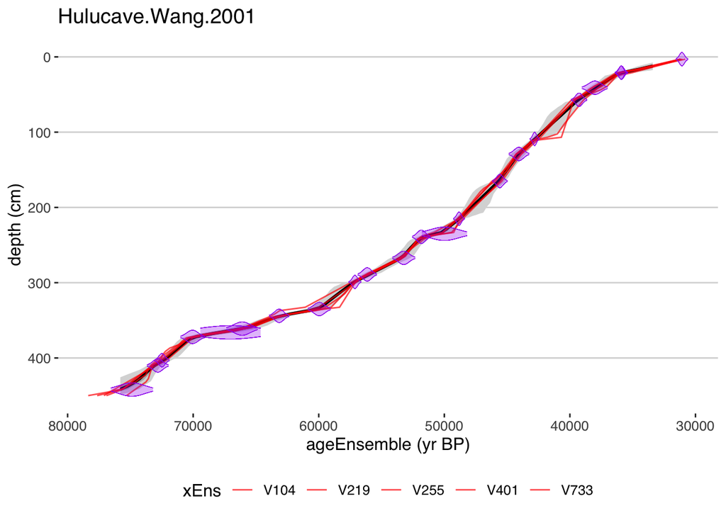

```r
plotChronEns(hulu,truncate.dist = 1e-4)
```

`plotChron()` is a wrapper for multiple plotting functions, and has a lot of options, which probably require tinkering to produce a nice plot. See all the options by running `?plotChron`

##Mapping the age ensemble to the paleoData measurements

The ensemble chronology in a chronModel may or may not have values corresponding to the paleoclimatic or paleoenvironmental measurements in paleoData. To map the model ensemble values to a measurement table in paleoData, use

```r
hulu = mapAgeEnsembleToPaleoData(hulu,age.var = "ageEnsemble",paleo.meas.table.num = 2)
```

##Selecting the variables of interest Let’s take a look at the this timeseries.

First we’re going to pull out the age ensemble and d18O data for future reference. The `selectData()` function makes this easy.

```r
hulu.ae <- selectData(hulu,var.name = "ageEnsemble",meas.table.num = 2)
```

```
## [1] "Found it! Moving on..."
```

```r
hulu.d18O<- selectData(hulu,var.name = "d18O",meas.table.num = 2)
```

```
## [1] "Found it! Moving on..."
```

##Creating a timeseries plot as a suite of lines

This might be a good time to take a peak at the data, lets plot the ensemble of lines for these

Here we will just plot 50 the data with 50 of its ensemble members.

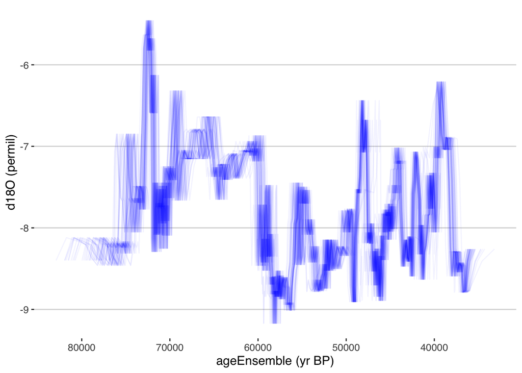

```r
hulu.ts.plot = plotTimeseriesEnsLines(X = hulu.ae,Y = hulu.d18O,alp = 0.05,n.ens.plot = 50,color = "blue")
hulu.ts.plot
```

##Creating a timeseries plot with a ribbon confidence intervals

We can also plot this as a ribbon plot of quantiles

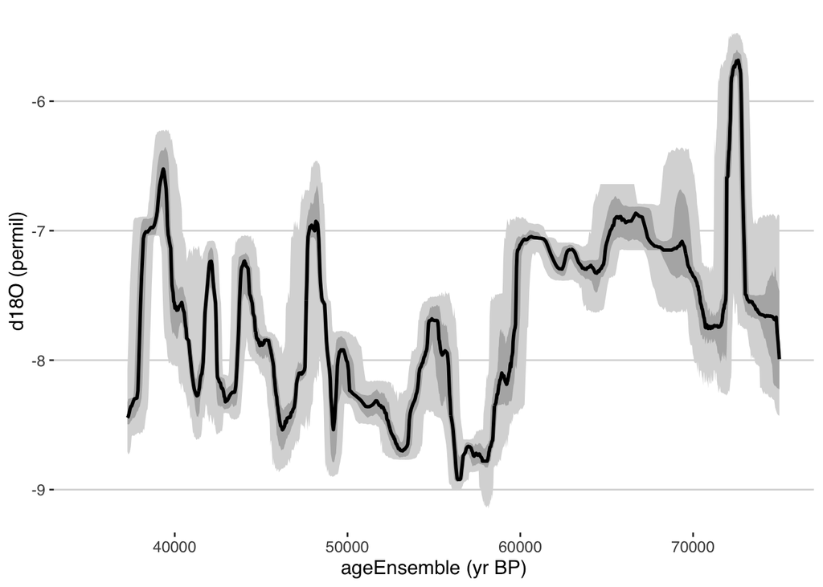

```r
hulu.ts.plot = plotTimeseriesEnsRibbons(X = hulu.ae,Y = hulu.d18O,n.bins = 1000)+xlim(c(35000,75000))
hulu.ts.plot
```

##Combining the two kinds of timeseries plots

Or a combination of the two with the “add.to.plot option”

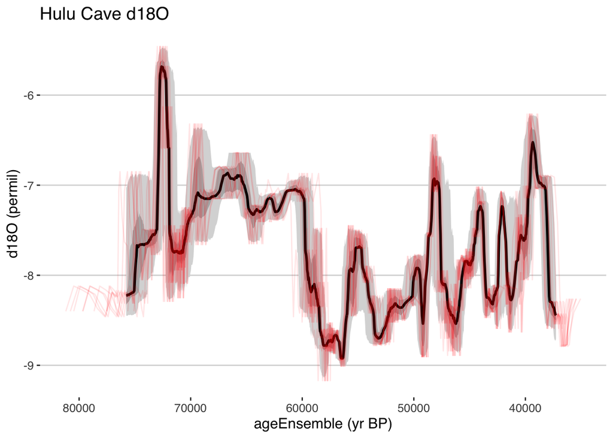

```r
hulu.ts.plot <- plotTimeseriesEnsLines(X = hulu.ae,Y = hulu.d18O,alp = 0.1,n.ens.plot = 10,color = "red",add.to.plot = hulu.ts.plot)+ggtitle("Hulu Cave d18O")
hulu.ts.plot
```

##Load in another dataset Let’s compare these data to the GISP2 ice core.

```r
gisp2 <- lipdR::readLipd("http://lipdverse.org/geoChronR-examples/GISP2.Alley.2000.lpd")
```

```
## [1] "reading: GISP2.Alley.2000.lpd"
```

##Use BAM (Banded Age Model) to create an age ensemble This is an ice core, so the chronology is not based on radiometric tie points. Let’s use BAM (Banded Age Model) to estimate a 2% counting uncertainty on this. Here we specify all the parameters so it runs in non-interactive mode.

```r
gisp2 = runBam(gisp2,
               paleo.num = 1,
               paleo.meas.table.num = 1,
               chron.num = 1,
               model.num = 1,
               ens.table.number = 1,
               make.new = T,
               n.ens = 1000,
               model = list(name = "poisson",
                            param = 0.02,
                            resize = 0,
                            ns = 1000)
               )
```

```
## [1] "Found it! Moving on..."
```

Because BAM runs off of the data in the paleo measurementTable, it puts the ageEnsemble straight into the paleoData, and we don’t need to run `mapAgeEnsembleToPaleoData()’.

You can also always use `selectData(gisp2)` in interactive mode, and it will list all of the variables.

##Select the relevant variables

```r
gisp2.d18O <- selectData(gisp2,var.name = "temp")
```

```
## [1] "Found it! Moving on..."
```

```r
gisp2.ens <- selectData(gisp2,var.name = "yearEnsemble")
```

```
## [1] "Found it! Moving on..."
```

```r
gisp2.ens$values[1:10,1:5]
```

```
##           [,1]     [,2]     [,3]     [,4]     [,5]
##  [1,] 1854.859 1854.859 1854.859 1854.859 1854.859
##  [2,] 1842.870 1842.870 1842.870 1842.870 1842.870
##  [3,] 1836.851 1836.851 1836.851 1836.851 1830.832
##  [4,] 1830.795 1830.795 1830.795 1830.795 1824.776
##  [5,] 1830.795 1830.795 1830.795 1830.795 1824.776
##  [6,] 1824.549 1824.549 1824.549 1824.549 1824.776
##  [7,] 1817.593 1817.593 1817.593 1817.593 1817.820
##  [8,] 1811.193 1811.193 1811.193 1811.193 1811.420
##  [9,] 1804.874 1804.874 1804.874 1804.874 1805.101
## [10,] 1797.737 1797.737 1797.737 1797.737 1797.964
```

Yep - that’s the first 10 entries of the first five age ensembles.

##Convert the ages from years AD to BP

Hey, it looks like those might be in calendar years instead of years BP. Let’s check the units

```r
gisp2.ens$units
```

```
## [1] "AD"
```

yep. We’d better convert it to BP for comparison with Hulu.

```r
gisp2.ens <- convertAD2BP(gisp2.ens)
```

##Plot the timeseries Let’s make another ribbon and lines plot, this time useing the magrittr pipe to streamline the process

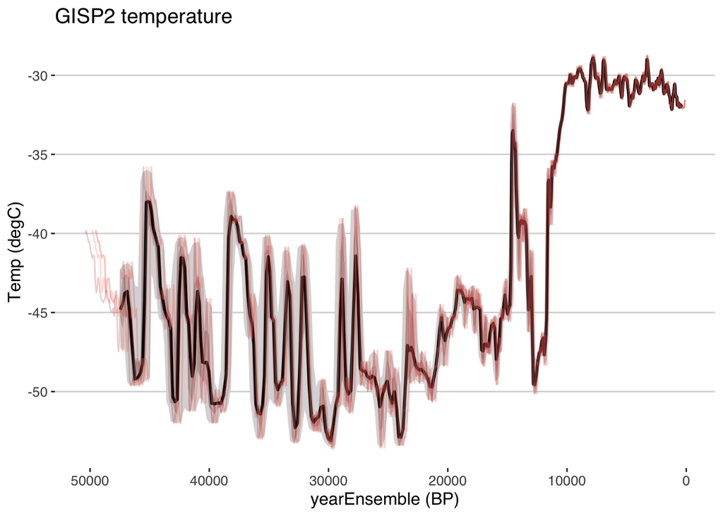

```r
gisp2.ts.plot <- plotTimeseriesEnsRibbons(X = gisp2.ens,Y = gisp2.d18O,n.bins = 500) %>%
  plotTimeseriesEnsLines(X = gisp2.ens,Y = gisp2.d18O,n.ens.plot = 5,color = "Reds",alp = .2)+
  ggtitle("GISP2 temperature")
print(gisp2.ts.plot)
```

##Compare the two timeseries Let’s compare the overlapping sections of these records, from about 36 to 50 kyr.

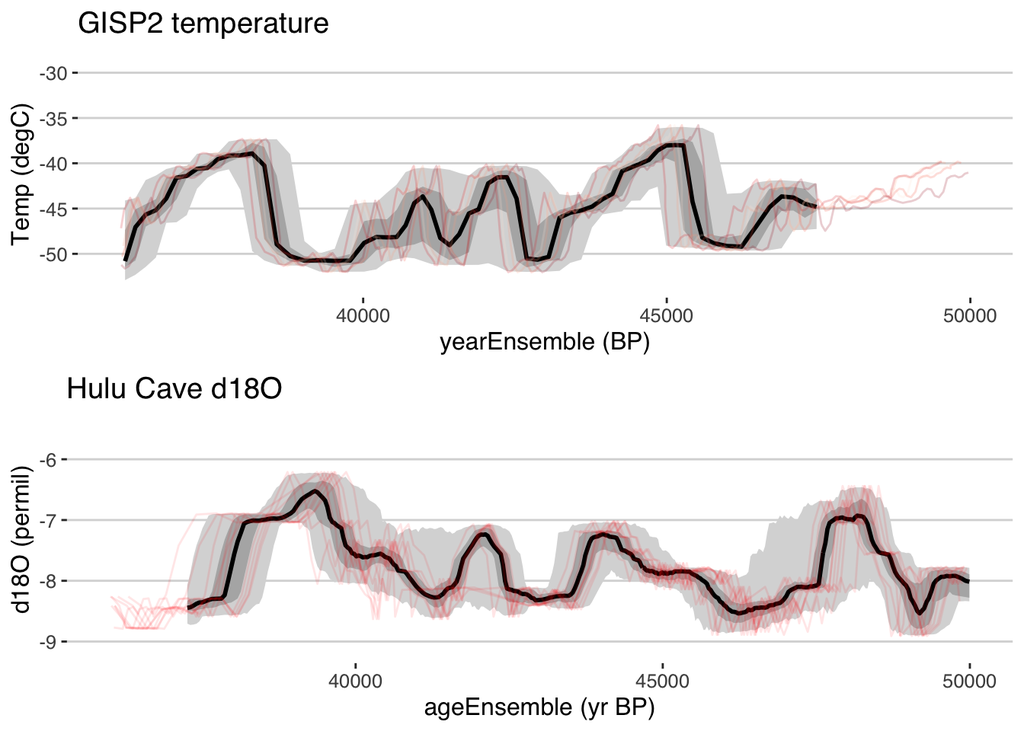

```r
library(gridExtra)
overlap <- c(36000,50000)
grid.arrange(grobs = list(gisp2.ts.plot+xlim(overlap),hulu.ts.plot+xlim(overlap)),nrow = 2)
```

Interesting. There’s a hint of a negative correlation during this time interval. Let’s calculate an ensemble correlation and see if shows up.

##Calculate the ensemble correlations

Here we specify the ensembles and data of each timeseries, and the width of the bins for correlation. More options are available in ?corEns

```r
corout <- corEns(gisp2.ens,gisp2.d18O,hulu.ae,hulu.d18O,bin.step = 500,max.ens = 100)
```

##Plot the ensemble correlation And now we summarize the results with plotCorEns(), illustrating significance after correcting for autocorrelation.

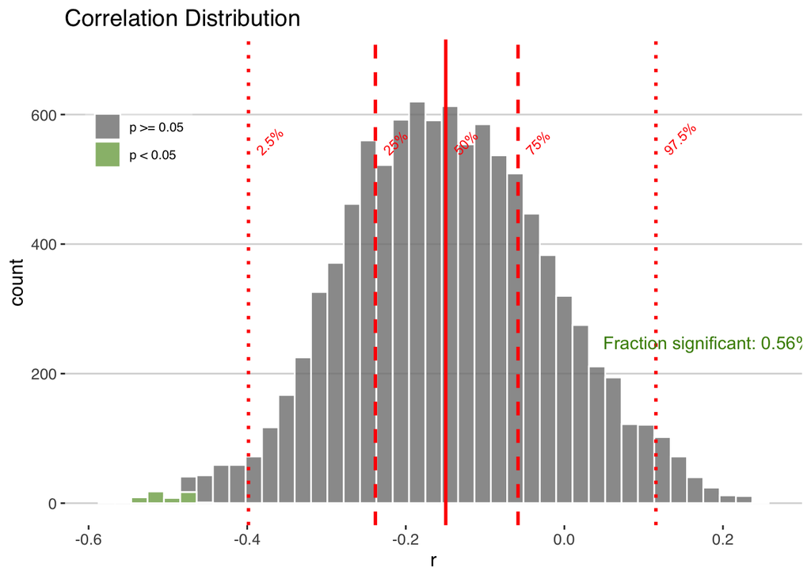

```r
plotCorEns(corout,legend.position = c(0.1, 0.8),significance.option = "autocorr")
```

And here we see that, indeed, given the age constraints and data used here, there two timeseries are unlikely correlated.

##End That wraps up ensemble correlation. Ready to move on to regression? The next vignette is here.